# Peer Assessment I

First, let us load the data and necessary packages:

```r
load("ames_train.Rdata")
library(caret)
library(MASS)
library(tidyverse)
```

# 1

Make a labeled histogram (with 30 bins) of the ages of the houses in the data set, and describe the distribution.

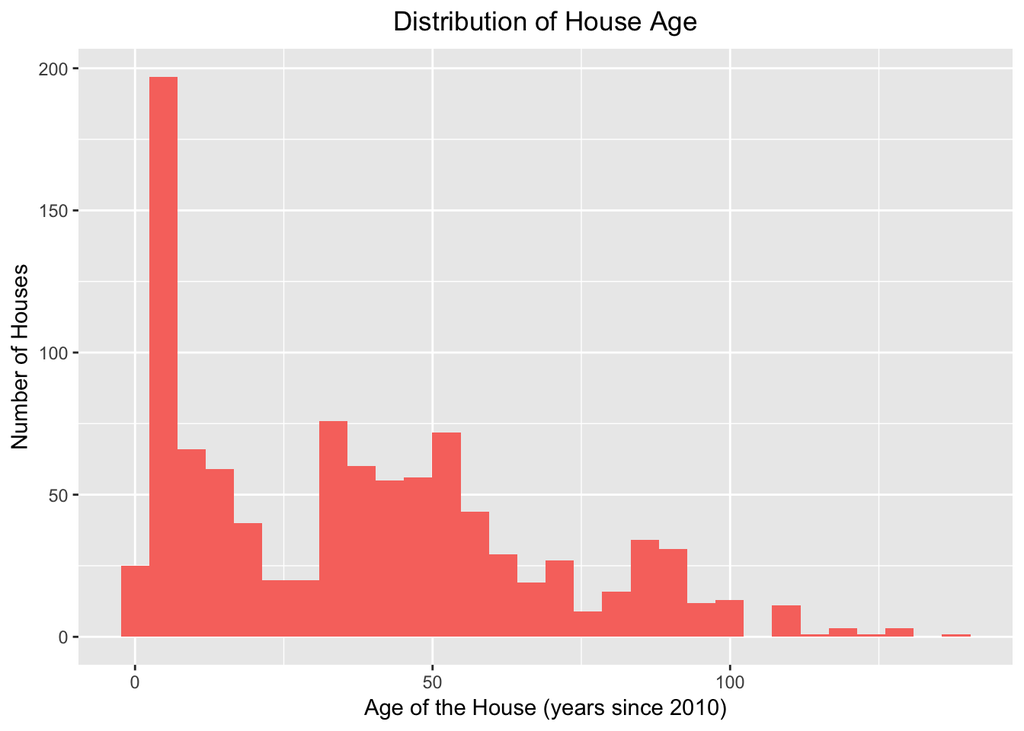

```r
ames_train %>%
        mutate(age = max(Year.Built) - Year.Built) %>%
        ggplot(aes(x=age)) +
            geom_histogram(bins=30, fill = '#F8766D') +
            theme(plot.title = element_text(hjust = 0.5)) +
            labs(title = "Distribution of House Age",
                 y = "Number of Houses",
                 x = "Age of the House (years since 2010)")
```

```r
glm_data = ames_train %>% mutate(age = max(Year.Built) - Year.Built) %>% group_by(age) %>% summarize(count = n())
fit_glm <- glm(count ~ age, data = glm_data, family = "poisson")
fit_nb <- glm.nb(count ~ age, data = glm_data)
print(paste("The dispersion parameter for a poisson model of counts by age is",format(summary(fit_glm)$deviance/summary(fit_glm)$df.residual, digits = 2)))
```

```
## [1] "The dispersion parameter for a poisson model of counts by age is 4.8"
```

```r
print(paste("The dispersion parameter for a negative binomial model of counts by age is",format(summary(fit_nb)$deviance/summary(fit_nb)$df.residual, digits = 2)))
```

```
## [1] "The dispersion parameter for a negative binomial model of counts by age is 1"
```

The distribution is right-skewed as there is a large number of new houses relative to old houses. While the number of houses for each age generally decreases as the age of the houses increase, the distribution is also multimodal as there are a couple of locally high counts of house at certain ages.

The common distribution for modeling count data is the Poisson distribution. However, one of the important assumptions of modeling data with Poisson distribution is that the dispersion parameter is about one. If this assumption is violated, a Poisson model will not adequately provide for overdispersed count data and will not model the mean-variance relationships in the data appropriately. The dispersion parameter, as calculated by the residual deviance divided by the residual degrees of freedom (df), for a Poisson model of counts by house age is 4.8, which is much greater than 1.0. A negative binomial model includes an extra parameter, theta, to allow the model to account for overdispersion. The dispersion parameter of a negative binomial model of counts by age is 1.0. Thus, the simple answer is to use a Poisson distribution for this data, but a negative binomial distribution would be preferred if there was a need to more accurately capture the dispersion of this particular count data.

# 2

The mantra in real estate is “Location, Location, Location!” Make a graphical display that relates a home price to its neighborhood in Ames, Iowa. Which summary statistics are most appropriate to use for determining the most expensive, least expensive, and most heterogeneous (having the most variation in housing price) neighborhoods? Report which neighborhoods these are based on the summary statistics of your choice. Report the value of your chosen summary statistics for these neighborhoods.

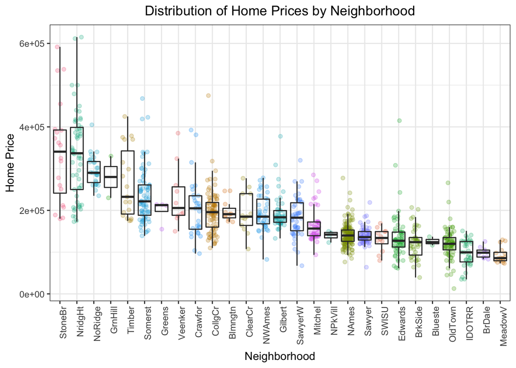

```r
median_data = ames_train %>%
    group_by(Neighborhood) %>%
    summarize(med_price = median(price), IQR_price = IQR(price))

cc = sample(colorspace::rainbow_hcl(27, c = 100, l=60,start = 0, end = 300), 27)
ames_train %>%
    left_join(median_data) %>%
    mutate(Neighborhood = reorder(Neighborhood, -med_price)) %>%
    ggplot(aes(x=Neighborhood, y = price)) +
    geom_jitter(aes(color=Neighborhood),alpha= 0.25, height = 0, width = 0.3) +
    geom_boxplot(fill=NA, outlier.shape=NA) +
    scale_color_manual(values = cc) +
    theme_bw() +
    theme(plot.title = element_text(hjust = 0.5), axis.text.x = element_text(angle = 90, hjust = 1)) +
    guides(fill=FALSE, color=FALSE) +
    labs(title = "Distribution of Home Prices by Neighborhood",
                 y = "Home Price",
                 x = "Neighborhood")
```

```r
# Most expensive by median
median_data %>% arrange(desc(med_price)) %>% .[1,c(1,2)]
```

```
## # A tibble: 1 x 2
##   Neighborhood med_price
##         <fctr>     <dbl>
## 1      StoneBr  340691.5
```

```r
# Least expensive by median
median_data %>% arrange(med_price) %>% .[1,c(1,2)]
```

```
## # A tibble: 1 x 2
##   Neighborhood med_price
##         <fctr>     <dbl>
## 1      MeadowV     85750
```

```r
# Most heterogenous by IQR
median_data %>% arrange(desc(IQR_price)) %>% .[1,c(1,3)]
```

```
## # A tibble: 1 x 2
##   Neighborhood IQR_price
##         <fctr>     <dbl>
## 1      StoneBr    151358
```

In order to determine the common prices of the houses in each neighborhood, a measure of center must be selected in order to compare the typical house price in each neighborhood. The two most common measures of center are the mean and median. In this case, the median will be used as the house prices for each neighborhood are not normally distributed. When data is not normally distributed the mean is often biased in the direction of the data’s skew. Thus, the median, which is not as sensitive to skew, is a better measure of center. Similarly, the interquartile range is a better measure of variability in non-normally distributed data as the standard deviation is similarly sensitive to skew and outliers as the mean.

# 3

Which variable has the largest number of missing values? Explain why it makes sense that there are so many missing values for this variable.

```r
# Six variables with the highest proportion of NAs
apply(ames_train, 2, function(x) mean(is.na(x))) %>% sort %>% tail
```

```
## Lot.Frontage Fireplace.Qu        Fence        Alley Misc.Feature
##        0.167        0.491        0.798        0.933        0.971
##      Pool.QC
##        0.997
```

Pool Quality, or “Pool.QC”, is the variable with the largest number of missing values. This number is likely high as “NA” is coded as “No Pool” in the data and most homes must not have a pool.

# 4

We want to predict the natural log of the home prices. Candidate explanatory variables are lot size in square feet (Lot.Area), slope of property (Land.Slope), original construction date (Year.Built), remodel date (Year.Remod.Add), and the number of bedrooms above grade (Bedroom.AbvGr). Pick a model selection or model averaging method covered in the Specialization, and describe how this method works. Then, use this method to find the best multiple regression model for predicting the natural log of the home prices.

```r
fit1 = train(log(price) ~ .,
                data = select(ames_train,price,Lot.Area,Land.Slope,Year.Built,Year.Remod.Add,Bedroom.AbvGr),
                method = "leapForward",
                tuneLength = 6,
                tuneGrid = data.frame(nvmax=c(1:6)),
                trControl = trainControl(method = "repeatedcv", number = 10, repeats = 10, verboseIter = FALSE),
                .method="adjr2",
                trace = TRUE,
                metric = "RMSE"
              )
fit1
```

```
## Linear Regression with Forward Selection
##
## 1000 samples
##    5 predictor
##
## No pre-processing
## Resampling: Cross-Validated (10 fold, repeated 10 times)
## Summary of sample sizes: 900, 901, 899, 900, 901, 900, ...
## Resampling results across tuning parameters:
##
##   nvmax  RMSE       Rsquared
##   1      0.3257448  0.4047185
##   2      0.3044382  0.4792399
##   3      0.2927750  0.5256906
##   4      0.2829671  0.5549514
##   5      0.2846634  0.5489266
##   6      0.2816330  0.5577529
##
## RMSE was used to select the optimal model using  the smallest value.
## The final value used for the model was nvmax = 6.
```

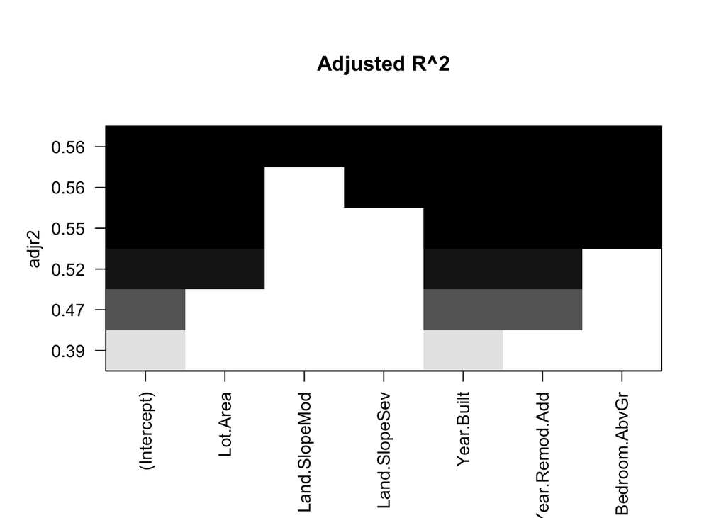

```r
plot(fit1$finalModel, scale = "adjr2", main = "Adjusted R^2")
```

I will use the forward selection method for adjusted R^2 to find the best model. This method works by adding explanatory variables one at a time, predicting the response variable, and comparing the changes to adjusted R^2 for each explanatory variable. For each round, one explanatory variable is added at a time and the explanatory variable that causes the greatest increase in adjusted R^2 for that round is added to the model. A new round is then started with the new model with the best explanatory variable from the prior round already added. The remaining explanatory variables are then added to this model and the changes in adjusted R^2 are again compared. This process repeats for as many rounds until adding another explanatory variable from the remaining options does not cause an increase in adjusted R^2 compared to the current model.

Running this process for the given variables using the `caret` package, the best model contains all six explanatory variables. Removing Land.SlopeMod or Land.SlopeMod and Land.SlopeSev, the extra levels of Land.Slope, may yield a similar model according to this method, but Land.SlopeGtl is the intercept value and, thus, Land.Slope cannot be removed unless this variable was split into three separate dummy variables.

# 5

Which home has the largest squared residual in the previous analysis (Question 4)? Looking at all the variables in the data set, can you explain why this home stands out from the rest (what factors contribute to the high squared residual and why are those factors relevant)?

```r
pred = predict(fit1)
resid = (log(ames_train$price) - pred)^2
row = which.max(resid)

paste("The predicted price for the house is",format(exp(predict(fit1,ames_train[row,])),big.mark=","))
```

```
## [1] "The predicted price for the house is 103,176.2"
```

```r
select(ames_train[row,],price,Lot.Area,Land.Slope,Year.Built,Year.Remod.Add,Bedroom.AbvGr)
```

```
## # A tibble: 1 x 6
##   price Lot.Area Land.Slope Year.Built Year.Remod.Add Bedroom.AbvGr
##   <int>    <int>     <fctr>      <int>          <int>         <int>
## 1 12789     9656        Gtl       1923           1970             2
```

The home with the largest squared residual is the house with PID 902207130, or row 428. The model predicts a price of $103,176.20 for this house, but the actual sale value was only $12,789. This house is likely an outlier and appears undervalued, especially as there is nothing unusual about the values of the six explanatory variables used in the model that would cause an excessively high price prediction. Looking at other information for this house, it was sold under abnormal conditions as a trade, foreclosure, or short sale, which may explain its excessively low sale price.

# 6

Use the same model selection method you chose in Question 4 to again find the best multiple regression model to predict the natural log of home prices, but this time **replacing Lot.Area with log(Lot.Area)**. Do you arrive at a model including the same set of predictors?

```r
ames_train$`log(Lot.Area)` = log(ames_train$Lot.Area)

fit2 = train(log(price) ~ . -Lot.Area,
                data = select(ames_train,price,Lot.Area,Land.Slope,Year.Built,Year.Remod.Add,Bedroom.AbvGr, `log(Lot.Area)`),
                method = "leapForward",
                tuneLength = 6,
                tuneGrid = data.frame(nvmax=c(1:6)),
                trControl = trainControl(method = "repeatedcv", number = 10, repeats = 10, verboseIter = FALSE),
                .method="adjr2",
                trace = TRUE,
                metric = "RMSE"
              )
fit2
```

```
## Linear Regression with Forward Selection
##
## 1000 samples
##    6 predictor
##
## No pre-processing
## Resampling: Cross-Validated (10 fold, repeated 10 times)
## Summary of sample sizes: 899, 899, 899, 901, 901, 900, ...
## Resampling results across tuning parameters:
##
##   nvmax  RMSE       Rsquared
##   1      0.3262096  0.4034064
##   2      0.2899889  0.5286059
##   3      0.2680895  0.5963495
##   4      0.2645341  0.6064581
##   5      0.2643994  0.6067313
##   6      0.2645907  0.6061591
##
## RMSE was used to select the optimal model using  the smallest value.
## The final value used for the model was nvmax = 5.
```

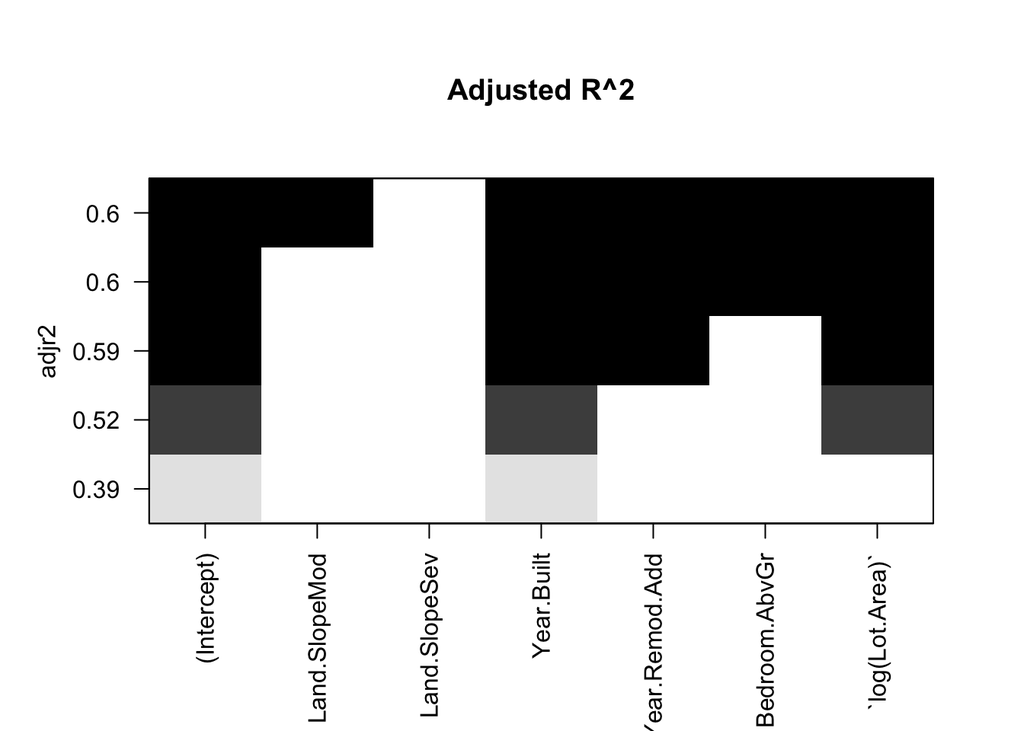

```r
plot(fit2$finalModel, scale = "adjr2", main = "Adjusted R^2")
```

Ultimately, the same set of predictors is in this model as before with the substitution of log(Lot.Area) for Lot.Area. Even though Land.SlopeSev, and Land.SlopeMod and Land.SlopeSev, are not included in the models with the highest adjusted R^2 values, Land.SlopeGtl is still the included intercept value. Thus, Land.Slope cannot be removed unless this variable was split into three separate dummy variables, so the model ends up having the same predictors.

# 7

Do you think it is better to log transform Lot.Area, in terms of assumptions for linear regression? Make graphs of the predicted values of log home price versus the true values of log home price for the regression models selected for Lot.Area and log(Lot.Area). Referencing these two plots, provide a written support that includes a quantitative justification for your answer in the first part of question 7.

```r
# RMSE and R^2 for model with Lot.Area
fit1$finalModel$xNames # confirm explanatory variables for fit1
```

```
## [1] "Lot.Area"       "Land.SlopeMod"  "Land.SlopeSev"  "Year.Built"
## [5] "Year.Remod.Add" "Bedroom.AbvGr"
```

```r
fit1$results[6,] # 10-fold cv results for final model with all explanatory variables is nvmax=6
```

```
##   nvmax     RMSE  Rsquared     RMSESD RsquaredSD
## 6     6 0.281633 0.5577529 0.03292024 0.05771911
```

```r
# RMSE and R^2 for model with log(Lot.Area)
fit2$finalModel$xNames # confirm explanatory variables for fit2
```

```
## [1] "Land.SlopeMod"   "Land.SlopeSev"   "Year.Built"      "Year.Remod.Add"
## [5] "Bedroom.AbvGr"   "`log(Lot.Area)`"
```

```r
fit2$results[6,] # 10-fold cv results for final model with all explanatory variables is nvmax=6
```

```
##   nvmax      RMSE  Rsquared     RMSESD RsquaredSD
## 6     6 0.2645907 0.6061591 0.02997915 0.05742403
```

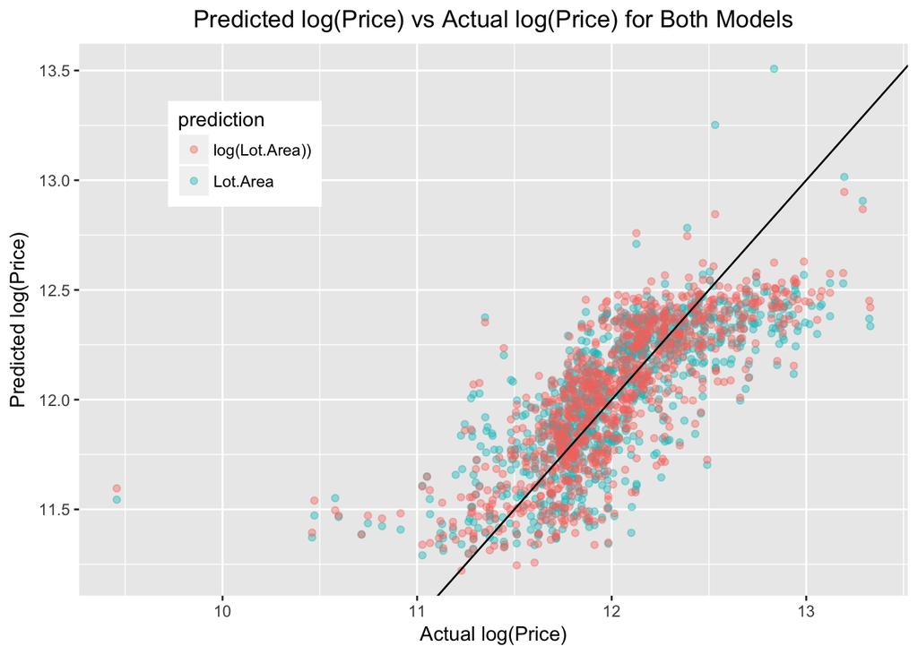

```r
true = log(ames_train$price)
pred1 = predict(fit1)
pred2 = predict(fit2)
plot_dat = data.frame(true=true, pred = c(pred1, pred2), prediction=c(rep(c("Lot.Area"),1000),rep(c("log(Lot.Area))"),1000)), diff=pred1-pred2)
ggplot(data=plot_dat, aes(x = true, y = pred, color = prediction)) +
    geom_point(,alpha = 0.4) +
    geom_abline(slope=1, intercept=0) +
    theme(legend.position=c(0.2, 0.8), plot.title = element_text(hjust = 0.5)) +
    labs(title = "Predicted log(Price) vs Actual log(Price) for Both Models", y = "Predicted log(Price)", x = "Actual log(Price)")
```

```
## Single numerical variable
## n = 2000, y-bar = 0, s = 0.0879
## H0: mu = 0
## HA: mu != 0
## t = 0, df = 1999
## p_value = 1
```

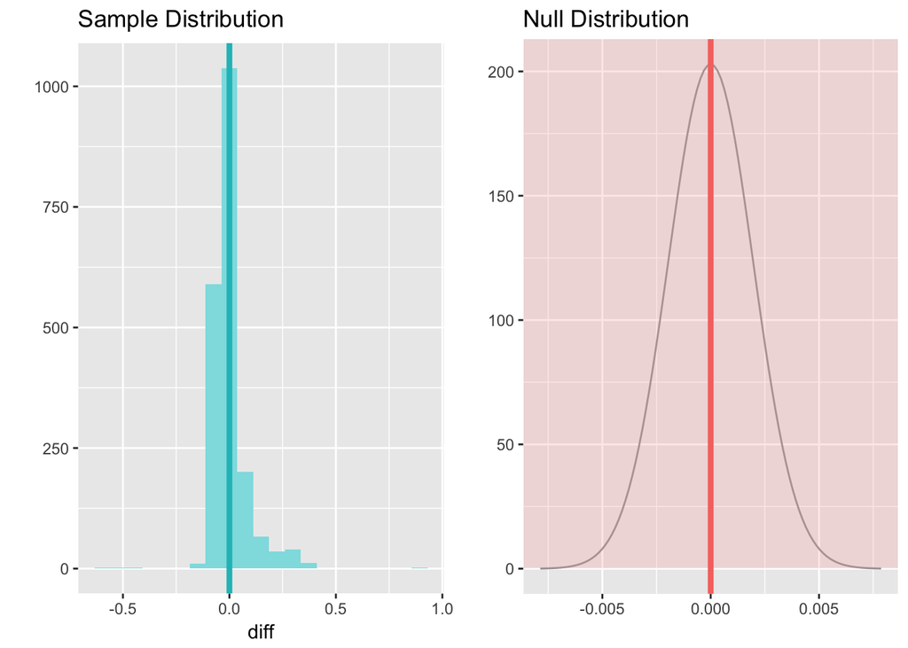

```r
statsr::inference(diff, data=plot_dat, type="ht", statistic = "mean", method="theoretical", alternative = "twosided", null = 0)
```

First, I confirm that my model variables `fit1` and `fit2` contain the right predictors, and then display the results for both RMSE and R^2 after 10-Fold Cross Validation. The model with the log transformation has a slightly lower RMSE value and a higher R^2 result, meaning the model with the log transformation has a slightly lower prediction error and better linear fit. From this fact alone, the log transformation is the better choice.

However, I want to qualify that using the plots alone to make this decision does not strongly support this conclusion. Both plots of the predicted prices versus actual prices for each model were included on the same plot, using opacity to overlay the results on top of each other. A y=x line was also added, which represents a model with a perfect prediction for all values of price. The plot emphasizes just how similar the results are for both models as the distribution of predicted values for each actual value of price for both models are almost identical. To statistically evaluate their similarity, I also conducted a hypothesis test with the null hypothesis that both results are actually equivalent (difference in means equal to zero). Sure enough, the p-value for this test is one, meaning there is not sufficient evidence to reject the null hypothesis and a statistically significant difference in results for both models could not be demonstrated.

Thus, from these 1000 data points, there is not sufficient evidence to add further complexity to the model by log transforming the `Lot.Area` variable as there is not a statistically significant difference in the distribution of results for both models. However, if one ignores this likelihood that the log transformation has better accuracy and a linear fit only by chance, a log transformation is the better choice. It may be worth it to explore those data points that give the distribution of Lot.Area feautres of an exponential distribution. These points may be outliers or so rare as to not merit log transforming all Lot.Area values to accomodate them.

### 7.0.1